# Relatorio 1va

Edivaldo Leitão

2023-01-06

### Questão 1

A tabela a seguir apresenta dados estatísticos sobre os enterococcus das praias filtradas a partir da cidade ‘ILHA COMPRIDA’, sendo a média entre os valores, a mediana que é o valor que fica exatamente na metade da amostra e Q1 e Q3 que representam valores que delimitam a amostra em até 25% e 75% respectivamente, além dos valores de máximo e mínimo, e desvio padrão para entender o valor de dispersão da amostra.

| Beach | media_Enterococcus | mediana_Enterococcus | maximo_Enterococcus | minimo_Enterococcus | Q1_Enterococcus | Q3_Enterococcus | Desvio_padrao |
| --- | --- | --- | --- | --- | --- | --- | --- |
| BALNEÁRIO ADRIANA | 25.15000 | 3.5 | 404 | 1 | 1.00 | 17.5 | 60.77203 |
| CENTRO | 33.82407 | 9.0 | 484 | 1 | 3.00 | 27.5 | 69.25071 |
| PONTAL | 18.92593 | 2.0 | 412 | 1 | 1.00 | 8.5 | 56.34717 |
| PRAINHA (BALSA) | 76.16667 | 14.0 | 1000 | 1 | 2.75 | 75.5 | 147.89498 |

### Questão 2

O gráfico de barras a seguir apresenta a quantidade de amostras de cada praia cidade de ‘ILHA COMPRIDA’ e mostra a proporção de cada barra em relação ao total da amostra, de forma decrescente.

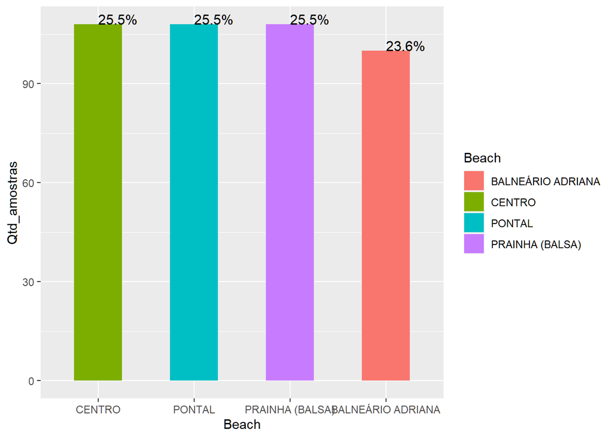

### Questão 3

O gráfico pizza a seguir mostra os mesmos dados do gráfico anterior, mas com uma visualização mais rápida de como se divide a amostra total.

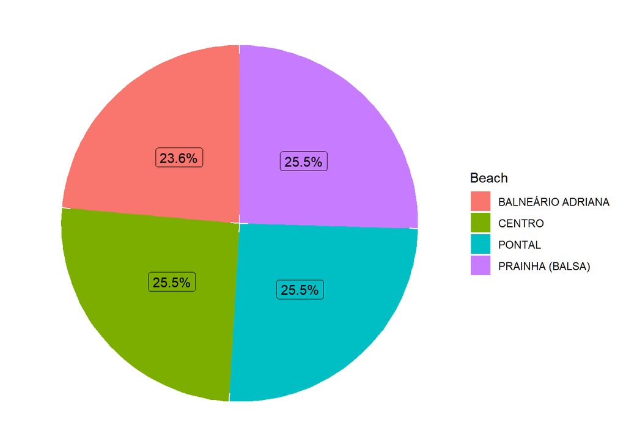

### Questão 4

O gráfico a seguir é um histograma que mostra a distribuição de frequência de cada praia, sendo o eixo Y a frequência e o eixo X a faixa de valor do enterococcus para praia que estão representadas com cores diferentes.

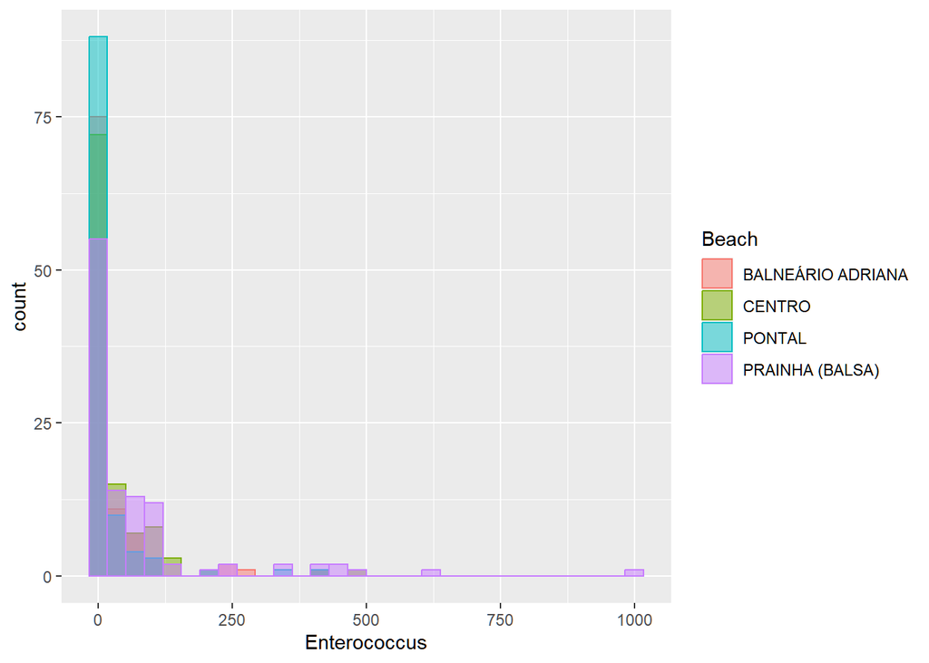

### Questão 5

O gráfico a seguir é um boxplot, que fornece informações sobre a distribuição da amostra, representando os valores mínimo e máximo assim como os quartis Q1 e Q3, além da mediana, de forma mais simples e rápida.

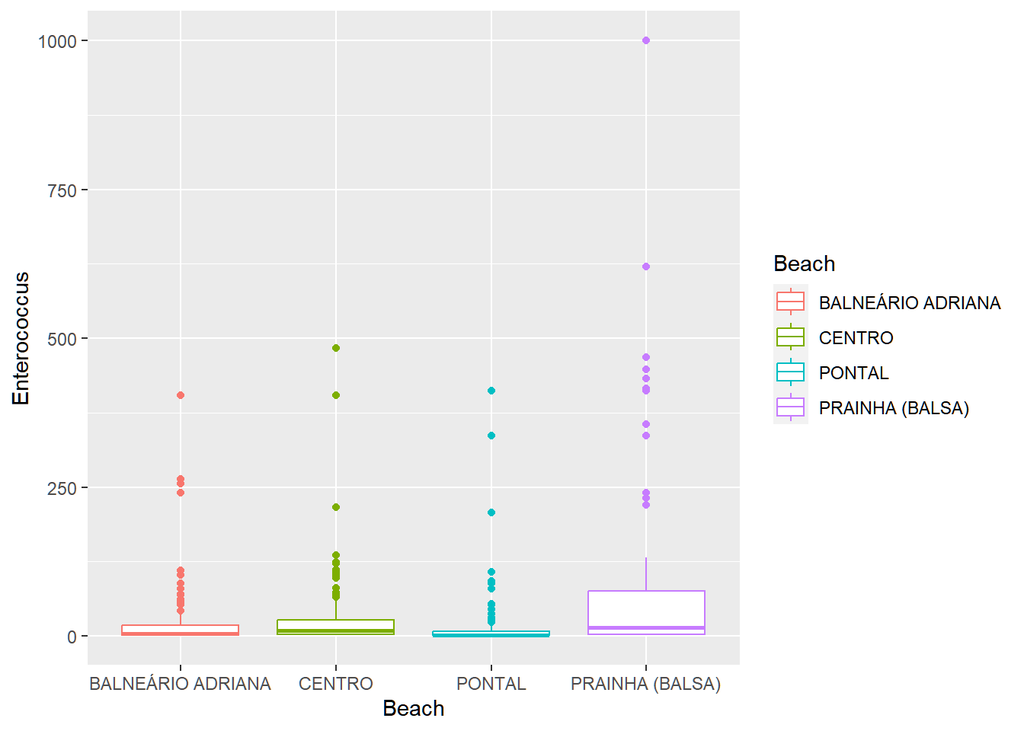